# MA641 Project Scratch

### ACF & PACF Plots

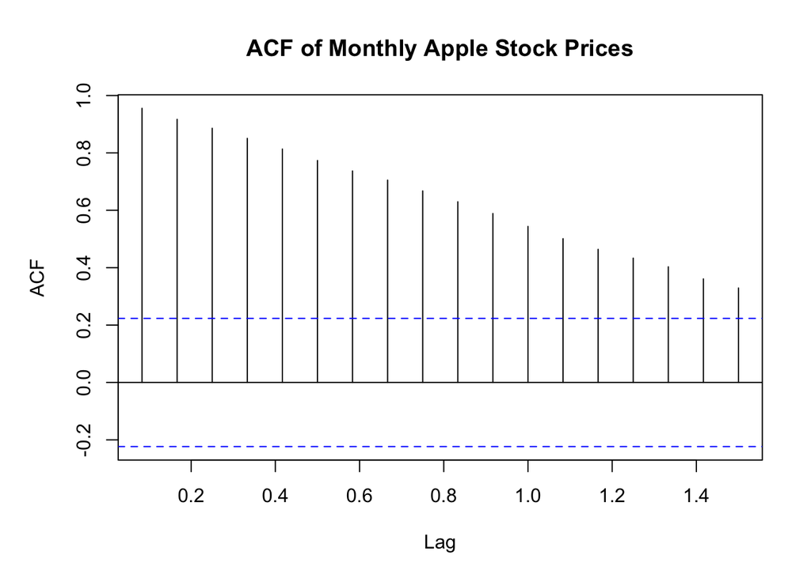

```r
# ACF and PACF Plots
par(mar=c(5, 5, 4, 2) + 0.1)
acf(ts_data, main="ACF of Monthly Apple Stock Prices")
```

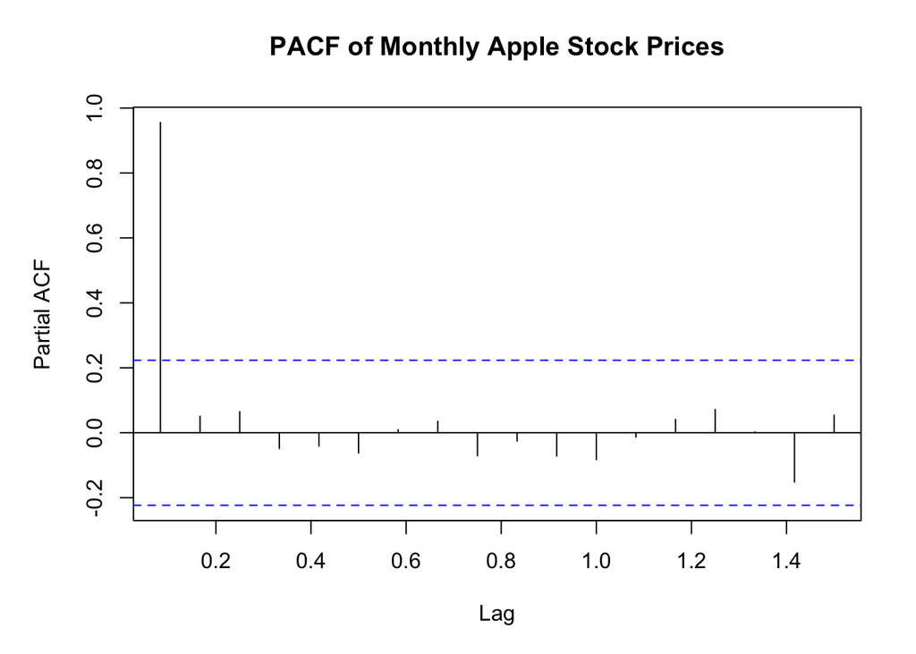

```r
pacf(ts_data, main="PACF of Monthly Apple Stock Prices")
```

```r
eacf(ts_data)
```

```
## AR/MA
##   0 1 2 3 4 5 6 7 8 9 10 11 12 13
## 0 x x x x x x x x x x x  x  x  x
## 1 o x o o o o o o o o o  o  o  o
## 2 x x o o o o o o o o o  o  o  o
## 3 o o o o o o o o o o o  o  o  o
## 4 x o o o o o o o o o o  o  o  o
## 5 o o o o o o o o o o o  o  o  o
## 6 o o o o o o o o o o o  o  o  o
## 7 o o o o o o o o o o o  o  o  o
```

ACF Plot:

- The gradual decay in the ACF indicates the presence of a trend component in the time series. The series is likely non-stationary.
- Significant autocorrelations suggest that the data is not random and past values can help predict future values.
- A high degree of positive autocorrelation at the first few lags implies momentum in the stock prices, which is common in financial time series.

PACF Plot:

- The sharp drop after the first lag in the PACF suggests that an AR(1) model may be appropriate for capturing the relationship in the data.
- The significant first lag indicates that the immediate past value has a strong influence on the current value, while the influence of values further in the past diminishes quickly.
- This pattern supports the use of a simple autoregressive model, as the complexity beyond the first lag does not add much explanatory power.

### ADF Test

```r
# Augmented Dickey-Fuller Test
adf_test <- adf.test(ts_data, alternative="stationary")
print(adf_test)
```

```
##
##  Augmented Dickey-Fuller Test
##
## data:  ts_data
## Dickey-Fuller = -2.1923, Lag order = 4, p-value = 0.497
## alternative hypothesis: stationary
```

- Since the p-value is greater than 0.05, we fail to reject the null hypothesis that the time series has a unit root. This indicates that the series is non-stationary.
- The non-stationarity observed from the ADF test results implies that differencing the time series is necessary to achieve stationarity.

```r
# Differencing the series if it is not stationary
if (adf_test$p.value > 0.05) {
  ts_data_diff <- diff(ts_data, differences=1)
  adf_test_diff <- adf.test(ts_data_diff, alternative="stationary")
  print(adf_test_diff)

  # Update the time series data to the differenced series
  ts_data <- ts_data_diff
}
```

```
##
##  Augmented Dickey-Fuller Test
##
## data:  ts_data_diff
## Dickey-Fuller = -4.3039, Lag order = 4, p-value = 0.01
## alternative hypothesis: stationary
```

- Since the p-value is less than 0.05, we reject the null hypothesis that the time series has a unit root. This indicates that the differenced series is stationary.
- With the differenced series being stationary, it is now suitable for fitting ARIMA models.